# Introducion

```r
library(car)
data$manufacturer<-recode(data$manufacturer,"'BOEING'='BOEING';'EMBRAER'='EMBRAER';'AIRBUS INDUSTRIE'='AIRBUS INDUSTRIE';'BOMBARDIER INC'='BOMBARDIER INC';'MCDONNELL DOUGLAS'='MCDONNELL DOUGLAS'; else='other'")
```

```r
summary(data)
```

```
##     Season      Weather     UniqueCarrier    FlightNum       TailNum
##  spring:6835   clear:9451   WN     :4911   Min.   :   2   N22909 :   60
##  summer:2412   fog  :2239   UA     :2995   1st Qu.: 521   N328AA :   60
##  winter:5550   rain :3107   AA     :2917   Median :1480   N332AA :   59
##                             OO     :1318   Mean   :2097   N12569 :   58
##                             XE     : 708   3rd Qu.:3001   N321AA :   58
##                             MQ     : 661   Max.   :7820   N14171 :   56
##                             (Other):1287                  (Other):14446
##             manufacturer                   aircraft_type
##  AIRBUS INDUSTRIE :1144                           : 1312
##  BOEING           :8333   Balloon                 :    6
##  BOMBARDIER INC   : 625   Fixed Wing Multi-Engine :13382
##  EMBRAER          :1862   Fixed Wing Single-Engine:   79
##  MCDONNELL DOUGLAS: 603   Rotorcraft              :   18
##  other            :2230
##
##         engine_type        Age        ActualElapsedTime CRSElapsedTime
##  Turbo-Fan    :8628   Min.   : 0.00   Min.   : 36.0     Min.   : 45.0
##  Turbo-Jet    :3744   1st Qu.: 6.00   1st Qu.: 68.0     1st Qu.: 70.0
##               :1312   Median :11.00   Median : 79.0     Median : 81.0
##  Turbo-Prop   : 976   Mean   :11.69   Mean   :122.6     Mean   :125.2
##  Reciprocating: 106   3rd Qu.:18.00   3rd Qu.:158.0     3rd Qu.:170.0
##  Turbo-Shaft  :  16   Max.   :52.00   Max.   :440.0     Max.   :360.0
##  (Other)      :  15   NA's   :1510    NA's   :34
##     AirTime         ArrDelay      Origin           Dest
##  Min.   :  0.0   Min.   :-44.00   LAX:14797   SFO    :2584
##  1st Qu.: 51.0   1st Qu.:  8.00               LAS    :1692
##  Median : 59.0   Median : 22.00               DEN    :1518
##  Mean   :100.3   Mean   : 36.63               ORD    :1461
##  3rd Qu.:134.0   3rd Qu.: 49.00               SJC    :1454
##  Max.   :370.0   Max.   :575.00               OAK    :1380
##  NA's   :34      NA's   :34                   (Other):4708
##     Distance       CarrierDelay    WeatherDelay        NASDelay
##  Min.   : 109.0   Min.   :  0.0   Min.   :  0.000   Min.   :  0.00
##  1st Qu.: 308.0   1st Qu.:  0.0   1st Qu.:  0.000   1st Qu.:  0.00
##  Median : 337.0   Median :  0.0   Median :  0.000   Median :  1.00
##  Mean   : 749.4   Mean   : 15.5   Mean   :  1.039   Mean   : 15.04
##  3rd Qu.:1235.0   3rd Qu.: 18.0   3rd Qu.:  0.000   3rd Qu.: 13.00
##  Max.   :2475.0   Max.   :536.0   Max.   :343.000   Max.   :362.00
##                   NA's   :5710    NA's   :5710      NA's   :5710
##  SecurityDelay    LateAircraftDelay Delay    Dep_Delay_Min
##  Min.   : 0.000   Min.   :  0.00    0:9391   Min.   :-44.00
##  1st Qu.: 0.000   1st Qu.:  0.00    1:5406   1st Qu.: -3.00
##  Median : 0.000   Median : 13.00             Median :  2.00
##  Mean   : 0.079   Mean   : 25.31             Mean   : 16.29
##  3rd Qu.: 0.000   3rd Qu.: 34.00             3rd Qu.: 24.00
##  Max.   :65.000   Max.   :466.00             Max.   :344.00
##  NA's   :5710     NA's   :5710               NA's   :47
```

```r
f<-ftable(data$Delay)
prop.table(f)
```

```
##          0         1
##
##  0.6346557 0.3653443
```

As we can see, 36.5% of cases are delayed flights.

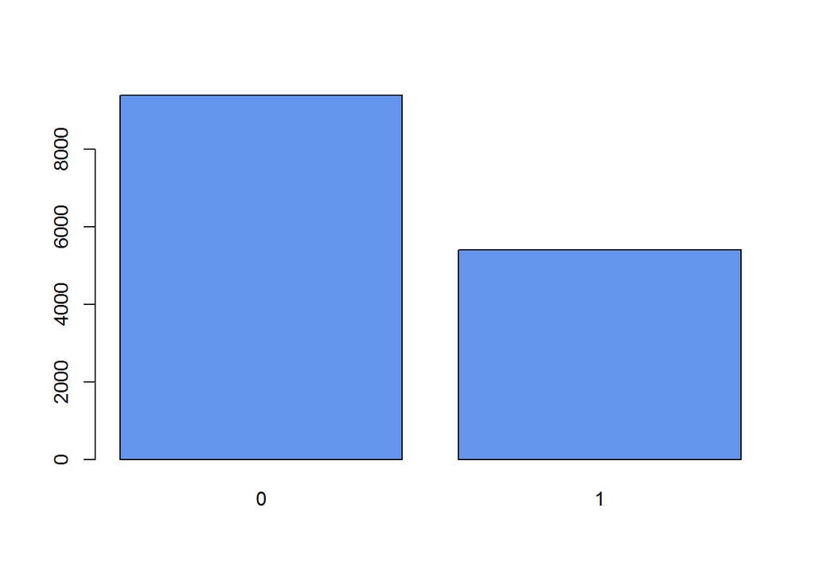

```r
plot(data$Delay,col="cornflowerblue" )
```

```r
str(data)
```

```
## 'data.frame':    14797 obs. of  23 variables:
##  $ Season           : Factor w/ 3 levels "spring","summer",..: 3 3 3 3 3 3 3 3 3 3 ...
##  $ Weather          : Factor w/ 3 levels "clear","fog",..: 1 1 1 1 1 1 1 1 1 1 ...
##  $ UniqueCarrier    : Factor w/ 12 levels "AA","AS","DL",..: 10 10 10 10 10 10 10 10 10 10 ...
##  $ FlightNum        : int  479 574 1004 1079 2021 2809 3144 184 303 430 ...
##  $ TailNum          : Factor w/ 2069 levels "N102UW","N103US",..: 1390 300 1546 418 961 367 203 889 1556 1667 ...
##  $ manufacturer     : Factor w/ 6 levels "AIRBUS INDUSTRIE",..: 2 2 2 2 2 2 2 2 2 2 ...
##  $ aircraft_type    : Factor w/ 5 levels "","Balloon","Fixed Wing Multi-Engine",..: 3 3 3 3 3 3 3 3 3 3 ...
##  $ engine_type      : Factor w/ 8 levels "","4 Cycle","None",..: 5 5 6 5 5 5 5 5 6 5 ...
##  $ Age              : num  12 22 8 19 3 20 1 4 20 9 ...
##  $ ActualElapsedTime: int  68 100 56 84 76 55 56 72 83 76 ...
##  $ CRSElapsedTime   : int  65 65 60 65 65 60 65 75 75 75 ...
##  $ AirTime          : int  47 44 42 43 42 43 42 62 66 65 ...
##  $ ArrDelay         : int  33 62 51 31 36 25 39 27 72 23 ...
##  $ Origin           : Factor w/ 1 level "LAX": 1 1 1 1 1 1 1 1 1 1 ...
##  $ Dest             : Factor w/ 10 levels "DEN","DFW","JFK",..: 4 4 4 4 4 4 4 5 5 5 ...
##  $ Distance         : int  236 236 236 236 236 236 236 337 337 337 ...
##  $ CarrierDelay     : int  16 13 0 11 7 0 11 0 0 7 ...
##  $ WeatherDelay     : int  0 0 0 0 0 0 0 0 0 0 ...
##  $ NASDelay         : int  3 35 4 19 11 0 0 0 13 1 ...
##  $ SecurityDelay    : int  0 0 0 0 0 0 0 0 0 0 ...
##  $ LateAircraftDelay: int  14 14 47 1 18 25 28 27 59 15 ...
##  $ Delay            : Factor w/ 2 levels "0","1": 2 2 2 2 2 2 2 2 2 2 ...
##  $ Dep_Delay_Min    : int  80 68 58 34 63 26 52 97 64 75 ...
```

# T-TEST between “Delay” and Numeric variables

```r
num<-sapply(data, is.numeric)
num<-names(data)[num==TRUE]
num
```

```
##  [1] "FlightNum"         "Age"               "ActualElapsedTime"
##  [4] "CRSElapsedTime"    "AirTime"           "ArrDelay"
##  [7] "Distance"          "CarrierDelay"      "WeatherDelay"
## [10] "NASDelay"          "SecurityDelay"     "LateAircraftDelay"
## [13] "Dep_Delay_Min"
```

```r
c<-c()
k1<-c()
for (i in num ){
  c<-t.test(data[,i]~data$Delay)$p.value
  k1<-c(k1,c)
}
names(k1)<-num
options(scipen=999)
sort(k1, decreasing=T)
```

```
##                                                                                                                                                                                                     WeatherDelay
## 0.924783661311439630914321696764091029763221740722656250000000…
##                                                                                                                                                                                                        FlightNum
## 0.229321146202203923758489167994412127882242202758789062500000…
##                                                                                                                                                                                                    SecurityDelay
## 0.148386475761621811075841037563805002719163894653320312500000…
##                                                                                                                                                                                                         ArrDelay
## 0.000249520364550613312024790468868218340503517538309097290039…
##                                                                                                                                                                                                LateAircraftDelay
## 0.000008924307469763787537160582008510800733347423374652862548…
##                                                                                                                                                                                                     CarrierDelay
## 0.000000030214458737665497872499492659770226055115927010774612…
##                                                                                                                                                                                                         NASDelay
## 0.000000022311829127953571216998185366975349097629077732563018…
##                                                                                                                                                                                                              Age
## 0.000000000000000000000000000000005282951787975973260719914081…
##                                                                                                                                                                                                         Distance
## 0.000000000000000000000000000000000000000000000000000000000000…
##                                                                                                                                                                                                          AirTime
## 0.000000000000000000000000000000000000000000000000000000000000…
##                                                                                                                                                                                                   CRSElapsedTime
## 0.000000000000000000000000000000000000000000000000000000000000…
##                                                                                                                                                                                                ActualElapsedTime
## 0.000000000000000000000000000000000000000000000000000000000000…
##                                                                                                                                                                                                    Dep_Delay_Min
## 0.000000000000000000000000000000000000000000000000000000000000…
```

As we can see from the table, there is significant relationship between the Delay and almost all numeric variables in the data. However, it is not reasonable to include all above mentioned variables(for example arrival delay(Arr Delay) and Delay of course are correlated, but Arr Delay does not explain reasons of Delay. Likewise we do not include variables ActualElapsedTime, FlightNum, AirTime,CRSElapsedTime). So, the numeric variables that should stay in the model are Distance and Age of the airplane.

# Chi-Square Test between “Delay” and Categorical variables

```r
chisq.test(data$Delay, data$aircraft_type)
```

```
##
##  Pearson's Chi-squared test
##
## data:  data$Delay and data$aircraft_type
## X-squared = 43.623, df = 4, p-value = 0.000000007682
```

```r
chisq.test(data$Delay,data$engine_type)
```

```
##
##  Pearson's Chi-squared test
##
## data:  data$Delay and data$engine_type
## X-squared = 388.15, df = 7, p-value < 0.00000000000000022
```

```r
chisq.test(data$Delay, data$Season)
```

```
##
##  Pearson's Chi-squared test
##
## data:  data$Delay and data$Season
## X-squared = 9.8194, df = 2, p-value = 0.007375
```

```r
chisq.test(data$Delay, data$UniqueCarrier)
```

```
##
##  Pearson's Chi-squared test
##
## data:  data$Delay and data$UniqueCarrier
## X-squared = 2021.4, df = 11, p-value < 0.00000000000000022
```

```r
chisq.test(data$Delay, data$manufacturer)
```

```
##
##  Pearson's Chi-squared test
##
## data:  data$Delay and data$manufacturer
## X-squared = 682.27, df = 5, p-value < 0.00000000000000022
```

As we can see from the Chi-squared test, all factor variables and delay are significantly related.

```r
set.seed(1)
trainingIndex<-createDataPartition(data$Delay, p=.75, list=FALSE)
Train<-data[trainingIndex,]
Test<-data[-trainingIndex,]
```

# Boxplots

Here are some plots to illustrate the relationships between variables.

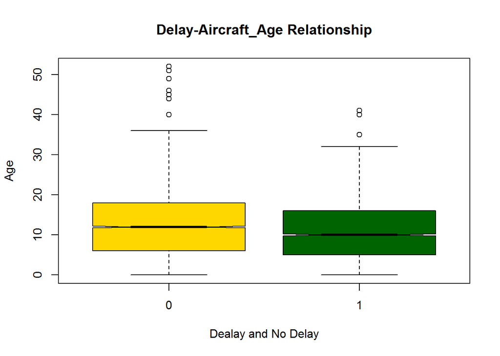

```r
boxplot(Train$Age~Train$Delay,xlab="Dealay and No Delay", ylab="Age", main= "Delay-Aircraft_Age Relationship",notch=TRUE,col=c("gold","darkgreen"))
```

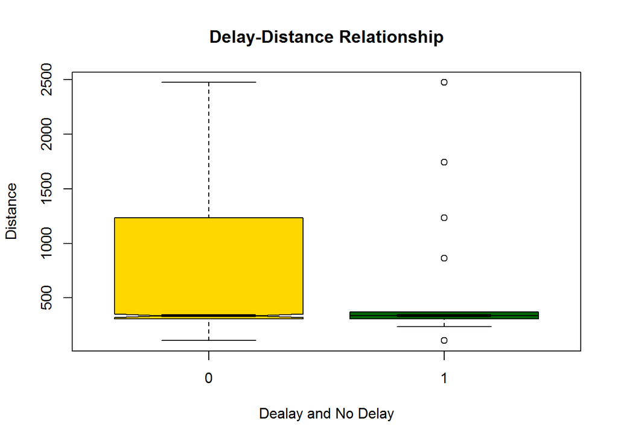

```r
boxplot(Train$Distance~Train$Delay,xlab="Dealay and No Delay", ylab="Distance", main= "Delay-Distance Relationship",notch=TRUE,col=c("gold","darkgreen"))
```

As we can see fromj two boxplots there is not much difference between median values, but in the second case the “NOT DELAY” has quite different range.

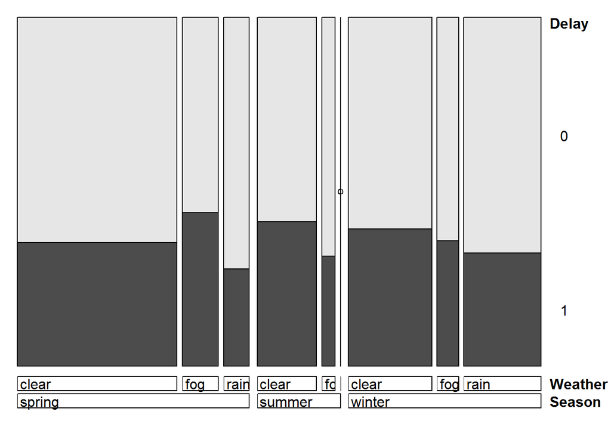

```r
doubledecker(Delay~ Season+Weather, data=Train)
```

With help of these diagram we can see conditional probabilities of Delay and No Delay. For example, in this case the weather and season variables are given and the diagram shows probabilities of Delay ant No Delay, the black part of a bar is a “1” or Delay and the white part is a “0” or No Delay . From this diagram we can see that if the season is spring and weather is fog than the probability of Delay is the highest. Basing on this information we suggested to increase number of employees in the service department in that time period by subcontracting them in order to decrease perceived delay time. The logic keeps true for the following two diagrams.

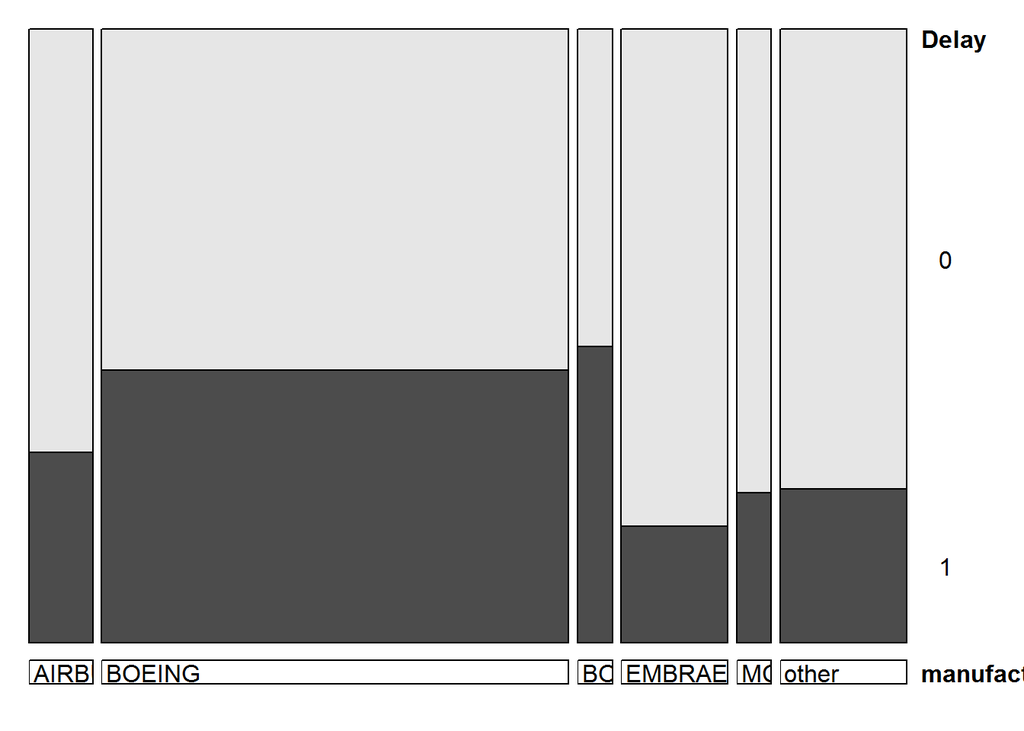

```r
doubledecker(Delay~ manufacturer, data=Train)
```

```r
summary(Train$manufacturer)
```

```
##  AIRBUS INDUSTRIE            BOEING    BOMBARDIER INC           EMBRAER
##               849              6220               464              1422
## MCDONNELL DOUGLAS             other
##               457              1687
```

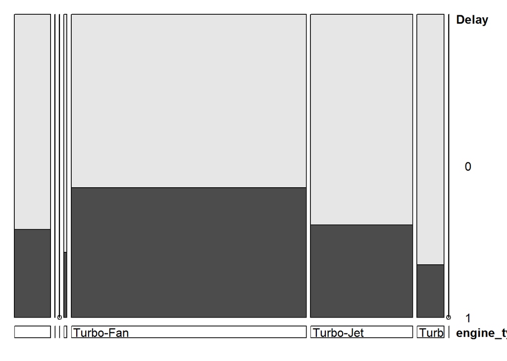

```r
doubledecker(Delay~engine_type, data=Train)
```

# Logistic regression

```r
paste(names(Train),collapse = "+")
```

```
## [1] "Season+Weather+UniqueCarrier+FlightNum+TailNum+manufacturer+aircraft_type+engine_type+Age+ActualElapsedTime+CRSElapsedTime+AirTime+ArrDelay+Origin+Dest+Distance+CarrierDelay+WeatherDelay+NASDelay+SecurityDelay+LateAircraftDelay+Delay+Dep_Delay_Min"
```

```r
frm<-"Delay~Season+Weather+manufacturer+Age+Dest+Distance+aircraft_type+UniqueCarrier+engine_type"
```

```r
set.seed(20)
logit_1<-glm(frm, Train, family="binomial")
summary(logit_1)
```

```
##
## Call:
## glm(formula = frm, family = "binomial", data = Train)
##
## Deviance Residuals:
##     Min       1Q   Median       3Q      Max
## -2.4277  -0.8559  -0.6022   0.9912   2.3738
##
## Coefficients: (3 not defined because of singularities)
##                                         Estimate Std. Error z value
## (Intercept)                            -0.216073   0.333135  -0.649
## Seasonsummer                            0.090582   0.065194   1.389
## Seasonwinter                            0.086301   0.054190   1.593
## Weatherfog                              0.077194   0.065086   1.186
## Weatherrain                            -0.161996   0.069511  -2.331
## manufacturerBOEING                      0.107073   0.115643   0.926
## manufacturerBOMBARDIER INC              1.132245   0.688591   1.644
## manufacturerEMBRAER                    -2.150187   1.167188  -1.842
## manufacturerMCDONNELL DOUGLAS           1.191550   0.251334   4.741
## manufacturerother                      -0.659594   0.231528  -2.849
## Age                                    -0.003449   0.004716  -0.731
## DestDFW                                 0.059987   0.185286   0.324
## DestJFK                                -1.422940   0.207061  -6.872
## DestLAS                                 0.085312   0.118157   0.722
## DestOAK                                 0.098762   0.121812   0.811
## DestORD                                 0.258404   0.118045   2.189
## DestPHX                                 0.175243   0.122644   1.429
## DestSAN                                -0.204719   0.251417  -0.814
## DestSFO                                 0.107980   0.098804   1.093
## DestSJC                                 0.122301   0.123277   0.992
## Distance                                      NA         NA      NA
## aircraft_typeBalloon                  -12.669226 266.810797  -0.047
## aircraft_typeFixed Wing Multi-Engine   -0.893540 586.231211  -0.002
## aircraft_typeFixed Wing Single-Engine   2.760900 586.230653   0.005
## aircraft_typeRotorcraft               -12.804459 238.747686  -0.054
## UniqueCarrierAS                         0.612976   0.483487   1.268
## UniqueCarrierDL                         1.204209   0.335657   3.588
## UniqueCarrierF9                         2.006767   0.331473   6.054
## UniqueCarrierMQ                         3.011340   1.223918   2.460
## UniqueCarrierNW                         2.440886   0.395086   6.178
```

[output cut: 53 more lines]

```
## engine_typeTurbo-Fan                              0.998318
## engine_typeTurbo-Jet                              0.998376
## engine_typeTurbo-Prop                             0.998797
## engine_typeTurbo-Shaft                                  NA
## ---
## Signif. codes:  0 '***' 0.001 '**' 0.01 '*' 0.05 '.' 0.1 ' ' 1
##
## (Dispersion parameter for binomial family taken to be 1)
##
##     Null deviance: 13198  on 9948  degrees of freedom
## Residual deviance: 11300  on 9909  degrees of freedom
##   (1150 observations deleted due to missingness)
## AIC: 11380
##
## Number of Fisher Scoring iterations: 12
```

```r
PredTest1<-predict(logit_1,newdata = Test, type="response")
table(PredTest1>0.5, Test$Delay)
```

```
##
##            0    1
##   FALSE 1522  449
##   TRUE   561  806
```

```r
pr_label1 <-ifelse(PredTest1>0.5, "1", "0")
library(caret)
confusionMatrix(pr_label1,Test$Delay, positive="1")
```

```
## Confusion Matrix and Statistics
##
##           Reference
## Prediction    0    1
##          0 1522  449
##          1  561  806
##
##                Accuracy : 0.6974
##                  95% CI : (0.6815, 0.713)
##     No Information Rate : 0.624
##     P-Value [Acc > NIR] : < 0.00000000000000022
##
##                   Kappa : 0.3664
##  Mcnemar's Test P-Value : 0.0004781
##
##             Sensitivity : 0.6422
##             Specificity : 0.7307
##          Pos Pred Value : 0.5896
##          Neg Pred Value : 0.7722
##              Prevalence : 0.3760
##          Detection Rate : 0.2415
##    Detection Prevalence : 0.4095
##       Balanced Accuracy : 0.6865
##
##        'Positive' Class : 1
##
```

As we want to make sure that this model is the best and there is no multicollinearity between variables, we want to find linearly dependent variables and remove them.

```r
ld.vars <- attributes(alias(logit_1)$Complete)$dimnames[[1]]
ld.vars
```

```
## [1] "Distance"               "engine_typeNone"
## [3] "engine_typeTurbo-Shaft"
```

So we will remove Distance and engine_type.

```r
frm2<-"Delay~Season+Weather+manufacturer+Age+Dest+aircraft_type+UniqueCarrier"
```

```r
set.seed(30)
logit_2<-glm(frm2, Train, family="binomial")
summary(logit_2)
```

```
##
## Call:
## glm(formula = frm2, family = "binomial", data = Train)
##
## Deviance Residuals:
##     Min       1Q   Median       3Q      Max
## -1.4852  -0.8558  -0.6016   0.9920   2.5110
##
## Coefficients:
##                                         Estimate Std. Error z value
## (Intercept)                            -0.139426   0.320383  -0.435
## Seasonsummer                            0.092628   0.065140   1.422
## Seasonwinter                            0.086909   0.054150   1.605
## Weatherfog                              0.080920   0.065011   1.245
## Weatherrain                            -0.163736   0.069432  -2.358
## manufacturerBOEING                      0.100674   0.106981   0.941
## manufacturerBOMBARDIER INC              1.007520   0.671823   1.500
## manufacturerEMBRAER                    -0.153944   0.702824  -0.219
## manufacturerMCDONNELL DOUGLAS           1.137763   0.242042   4.701
## manufacturerother                      -0.743044   0.211174  -3.519
## Age                                    -0.003317   0.004402  -0.754
## DestDFW                                 0.066459   0.184824   0.360
## DestJFK                                -1.428247   0.205761  -6.941
## DestLAS                                 0.089852   0.117868   0.762
## DestOAK                                 0.104834   0.121586   0.862
## DestORD                                 0.264422   0.117106   2.258
## DestPHX                                 0.180074   0.122425   1.471
## DestSAN                                -0.202470   0.251319  -0.806
## DestSFO                                 0.107278   0.098399   1.090
## DestSJC                                 0.124743   0.122963   1.014
## aircraft_typeBalloon                  -12.668633 266.887112  -0.047
## aircraft_typeFixed Wing Multi-Engine   -2.156791   0.338178  -6.378
## aircraft_typeFixed Wing Single-Engine   0.369075   0.380669   0.970
## aircraft_typeRotorcraft               -13.632109 198.520890  -0.069
## UniqueCarrierAS                         0.607269   0.471220   1.289
## UniqueCarrierDL                         1.195176   0.327308   3.652
## UniqueCarrierF9                         2.033510   0.312509   6.507
## UniqueCarrierMQ                         1.004608   0.729771   1.377
## UniqueCarrierNW                         2.421726   0.389265   6.221
## UniqueCarrierOO                         1.220545   0.694483   1.757
```

[output cut: 37 more lines]

```
## UniqueCarrierUS                           0.00000217878388 ***
## UniqueCarrierWN                       < 0.0000000000000002 ***
## UniqueCarrierXE                                   0.252490
## UniqueCarrierYV                                   0.554600
## ---
## Signif. codes:  0 '***' 0.001 '**' 0.01 '*' 0.05 '.' 0.1 ' ' 1
##
## (Dispersion parameter for binomial family taken to be 1)
##
##     Null deviance: 13198  on 9948  degrees of freedom
## Residual deviance: 11311  on 9914  degrees of freedom
##   (1150 observations deleted due to missingness)
## AIC: 11381
##
## Number of Fisher Scoring iterations: 12
```